# Survival Analysis

## Cox proportional hazards model

Given the hazard function $\lambda(t)$, which denotes the event rate at time $t$ conditional on survival until that time, the Cox proportional hazards model models the hazard function as follows:
$$\lambda(t)=\lambda_0(t)exp(\beta_1x_1+...+\beta_nx_n)$$
Here $\lambda_0(t)$ is a base hazard function that is further scaled up or down per timestep depending on the covariates $x_1,...,x_n$ and coefficients $\beta_1,...,\beta_n$. Note that if we have two different groups with two different hazard functions $\lambda_a(t)$ and $\lambda_b(t)$, the proportion of the two hazard functions will be time-independent.

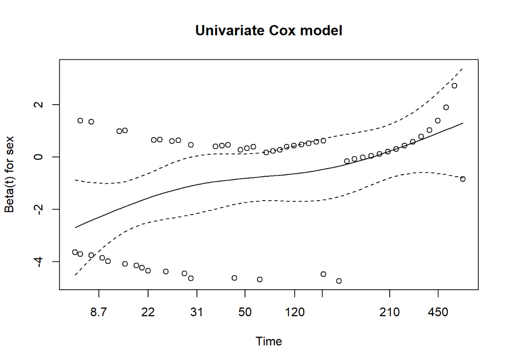

```r
#par(mfrow=c(2,1))

#Univariate Cox model in which sex is used as covariate
cox_fit_uni<-coxph(Surv(time, status) ~ sex, data = kidney)
#plot also shows confidence interval
fit_sex<-cox.zph(cox_fit_uni)
#Note that the plot shows a clear slope, this is an indication that the sex covariate is statistically significant
plot(fit_sex,main="Univariate Cox model")
```

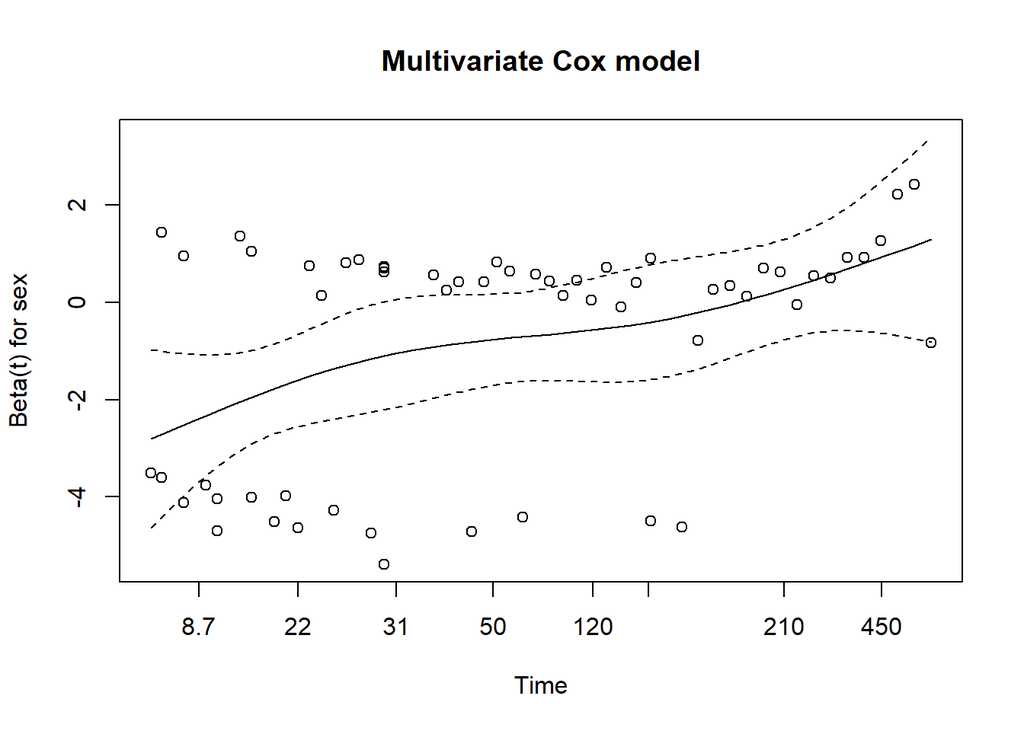

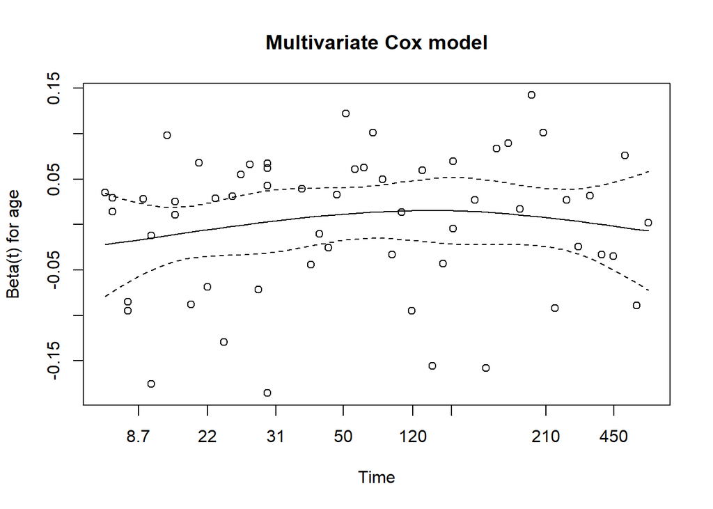

```r
#Multivariate Cox model in which sex, age are used as covariate
cox_fit_mult<-coxph(Surv(time, status) ~ sex+age, data = kidney)
#plot also shows confidence interval
fit_age_sex<-cox.zph(cox_fit_mult)
plot(fit_age_sex,main="Multivariate Cox model")
```

```r
#Note that the age covariate is not significant, this can also be seen from the plot as the plot is quite flat and doesn't indicate a significant slope.
print(cox_fit_mult)
```

```
## Call:
## coxph(formula = Surv(time, status) ~ sex + age, data = kidney)
##
##          coef exp(coef)  se(coef)      z       p
## sex -0.829314  0.436349  0.298955 -2.774 0.00554
## age  0.002032  1.002034  0.009246  0.220 0.82607
##
## Likelihood ratio test=7.12  on 2 df, p=0.02849
## n= 76, number of events= 58
```

```r
#We can perform statistical tests in order to see whether the difference between survival curves of different groups is statistically significant.
#See below that for the covariate sex this is indeed the case. Note that a likelihood ratio
#test, Wald test and logrank test are given, all of being highly significant
summary(cox_fit_uni)
```

```
## Call:
## coxph(formula = Surv(time, status) ~ sex, data = kidney)
##
##   n= 76, number of events= 58
##
##        coef exp(coef) se(coef)      z Pr(>|z|)
## sex -0.8377    0.4327   0.2966 -2.824  0.00474 **
## ---
## Signif. codes:  0 '***' 0.001 '**' 0.01 '*' 0.05 '.' 0.1 ' ' 1
##
##     exp(coef) exp(-coef) lower .95 upper .95
## sex    0.4327      2.311    0.2419    0.7738
##
## Concordance= 0.636  (se = 0.035 )
## Likelihood ratio test= 7.07  on 1 df,   p=0.008
## Wald test            = 7.98  on 1 df,   p=0.005
## Score (logrank) test = 8.4  on 1 df,   p=0.004
```

## Main References

- Survival analysis in R for Public Health, Imperial College London
- ‘Survival’ package in R (version 3.1-12), Terry M Therneau